# Practical Machine Learning Course Project: Predicting Classes

Kurtis Pivert

4/21/2017

## Research Question

Is it possible to predict what class an data observation belongs to? Using data obtained from accelerometers mounted on 6 weight lifters and the dumb bells used to perform the exercise, this report outlines the approach used to predict the label (`classe`, 5 different categories indicating if the subject performed the exercise correctly) according to selected features from an individual observation of the data captured in the exercise record.

```r
        ## Load Required Packages

        require(tidyverse)
        require(extrafont)
        require(knitr)
        require(caret)
        loadfonts(quiet = TRUE)
        require(rattle)
        require(parallel)
        require(doParallel)
        require(rpart)
        require(RGtk2)
```

## Data Used in This Report

The data set for this project was acquired from [GroupWare@LES](http://groupware.les.inf.puc-rio.br/har). It consists of the `training` (19622 observations of 160 variables) and `testing` (20 observations of 160 variables) data sets. The `testing` set will only be used once after completion of model building.

```r
        ## Load Data Sets

        training <- read.csv("/Users/kpivert/Documents/Coursera/Course 2/practicalmachinelearning/pml-training.csv",
                na.strings = "NA")

        testing <- read.csv("/Users/kpivert/Documents/Coursera/Course 2/practicalmachinelearning/pml-testing.csv",
                na.strings = "NA")
```

### Exploratory Data Analysis

After reviewing the data using `str` and `summary`, all summary statistic data was removed (variables prefixed with `kurtosis_`, `skewness_`, `amplitude_`, `max_`, `min_`, `amplitude_`, `var_`, `avg_`, `stddev_`). Nearly all of the variables eliminated from inclusion in the modeling process contained 1000s of blank cells or the `#DIV/0!` Excel warning. These features were removed from both the `training` and `testing` sets, leaving 60 features for inclusion in model building.

```r
        ## Examine Dataset

        str(training[1:50])
        summary(training[1:50])

        str(training[51:100])
        summary(training[51:100])

        str(training[101:160])
        summary(training[101:160])
```

```r
        ## Using Solution from Stackexchange:
        ## http://stackoverflow.com/questions/7597559/grep-using-a-character-vector-with-multiple        -patterns

        ## ID Names of Summary Statistic Variable Columns
        sumStats <- c("kurtosis_", "skewness_", "max_", "min_", "amplitude_",
              "var_", "avg_", "stddev_")

        sumStatsCols <- grep(paste(sumStats, collapse = "|"), names(training))

        ## Remove Columns

        training <- training %>% select(-sumStatsCols)
        testing <- testing %>% select(-sumStatsCols)
```

### Near-Zero Variance

After removing the summary statistic variables, only 1 feature with near-zero variance remains and is removed as well as the `X` variable, which is only an oberservation number. This leaves 57 features for inclusion in a model to predict classification of the new records in the `testing` data.

```r
                ## Determine Which Variables Have Near-Zero Variance

                nearZeroVar(training)
```

```
## [1] 6
```

```r
                training <- training[,-c(1,6)]
                testing <- testing[,-c(1,6)]

                ## Rerun Function: No NZV Variables Left
                nearZeroVar(training)
```

```
## integer(0)
```

## Divide Training Data into Training and Testing Sets

```r
        ## Set Seed

        set.seed(562013)

        inTrain <- createDataPartition(training$classe, p = 0.7, list = FALSE)

                trainSet <- training[inTrain,]
                testSet <- training[-inTrain, ]
```

## Model Building and Out-of-Sample Error Rate

Using the `caret` package, three classifcation models will be built on the `trainSet` data. The accuracy of the classification, and estimate of out-of-sample error rate, will be determined on the `testSet` data and the most accurate model will be applied to the `testing` set.

### Preprocessing

Because may of the data are skewed (see the figure of belt acclerometer in the x plane), data will be centered and scaled (ignoring factors) before being used in the modeling process.

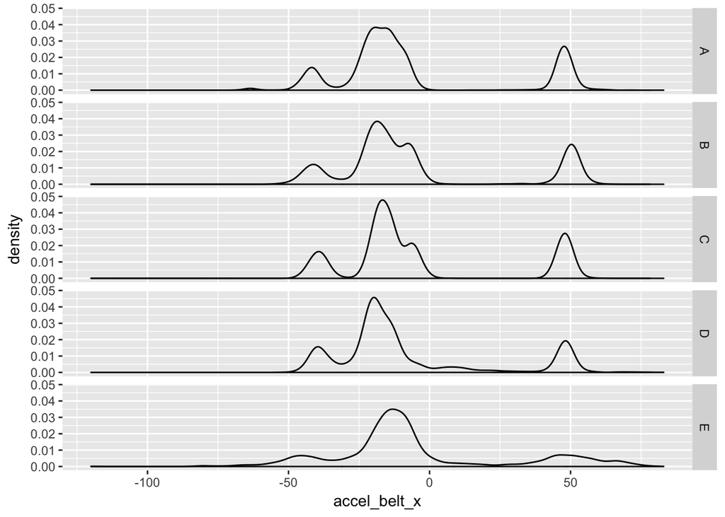

### Cross-Validation

Models will be cross-validated using k-folds cross-validation to help select the best classifying model. The number of folds used is 10.

```r
fitControl <- fitControl <- trainControl(method = "cv",
                                         number = 10,
                                         allowParallel = TRUE)
```

## Model 1: CART

All classification models will use parallel processing to reduce the time required. The first model used is a Classification and Regression Tree approach.

Using the `testSet` data the accuaracy is low at 57.2%, with an estimated out-of-sample error rate of >42.8%.

```r
                ## Set Up Parallel Processing

                detectCores()
                cluster <- makeCluster(detectCores()-1)
                registerDoParallel(cluster)

                ## Create Model

                set.seed(562013)

                mod1 <- train(classe ~ ., data = trainSet, method = "rpart",
                              trControl= fitControl, preProcess = c("center", "scale"))

                ## Stop Cluster

                stopCluster(cluster)
                registerDoSEQ()

                ## Predict on Test Set and Use Confusion Matrix

                mod1Pred <- predict(mod1, testSet)
                confusionMatrix(mod1Pred, testSet$classe)
```

[output not shown]

## Model 2: Random Forests

```r
                ## Set Up Parallel Processing

                detectCores()
                cluster <- makeCluster(detectCores()-1)
                registerDoParallel(cluster)

                ## Create Model
                x <- trainSet[, -58]
                y <- trainSet[,58]

                set.seed(562013)
                mod2 <- train(x, y, data = trainSet, method = "rf",
                              trControl= fitControl, preProcess = c("center", "scale"))

                ## Stop Cluster

                stopCluster(cluster)
                registerDoSEQ()

                ## Predict on Test Set and Use Confusion Matrix

                mod2Pred <- predict(mod2, testSet)
                confusionMatrix(mod2Pred, testSet$classe)
```

[output not shown]

## Model 3: Stochastic Gradient Boosting

```r
                ## Set Up Parallel Processing

                detectCores()
                cluster <- makeCluster(detectCores()-1)
                registerDoParallel(cluster)

                ## Create Model

                set.seed(562013)

                mod3 <- train(classe ~ ., data = trainSet, method = "gbm",
                              trControl= fitControl, preProcess = c("center", "scale"))

                ## Stop Cluster

                stopCluster(cluster)
                registerDoSEQ()

                ## Predict on Test Set and Use Confusion Matrix

                mod3Pred <- predict(mod3, testSet)
                confusionMatrix(mod3Pred, testSet$classe)
```

[output not shown]

## Model Selection

Using the most accurate model, Random Forests, yields the following labels for the testing set.

| testing Observation | Predicted Class |
| --- | --- |
| 1 | B |
| 2 | A |
| 3 | B |
| 4 | A |
| 5 | A |
| 6 | E |
| 7 | D |
| 8 | B |
| 9 | A |
| 10 | A |
| 11 | B |
| 12 | C |
| 13 | B |
| 14 | A |
| 15 | E |
| 16 | E |
| 17 | A |
| 18 | B |
| 19 | B |
| 20 | B |

Looking at the top 5 important variables we find they are:

| Variable | Importance |
| --- | --- |
| cvtd_timestamp | 100.000 |
| raw_timestamp_part_1 | 73.328 |
| roll_belt | 31.502 |
| num_window | 31.226 |
| magnet_dumbbell_y | 15.912 |

[figure not shown]

```r
  featurePlot(x = trainSet[,c("cvtd_timestamp", "raw_timestamp_part_1", "roll_belt", "num_window",
               "magnet_dumbbell_y")], y = trainSet$classe, plot = "pairs")
```

## Conclusion

Using complex, yet less interpretable models such as Random Forests and GBM, yield high accuracy according to the estimated out-of-sample error rates.